# Project 1: Can we predict who is likely to leave the bank?

Chris Bowne

It is cheaper to retain customers than aquire them. Just like any business, banks wish to limit customer exits (the churn) by predicting who is at risk.

# Question

Can we predict who is likely to leave the bank?

# Data

10,000 customer accounts defined by 11 variables. Split into training and testing. Outcome variable is binary: true if customer leaves bank. The data set is free of empty fields.

# Model

After backwards elimination and examination of interactions we arrived at a model as seen here. Strongest predictors were whether or not a customer was “active” or not. The interaction between the number of products a customer had and whether they had a checking account or not also changed the odds of exit considerably.

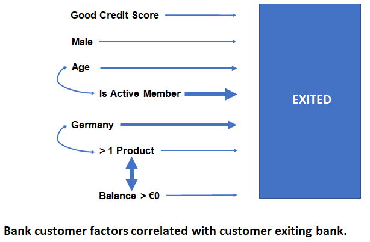

Logistic Model Diagram

# Prediction outcomes

Model correctly predicts a customer will leave 34% of the time. The overall correct prediction rate is 84%. The model is not successful at predicting who will leave.

```r
library(car)
library(caret)
library(fastDummies)
library(PerformanceAnalytics)
library(rcompanion)
library(readr)
library(ROCR)
library(tidyverse)
```

```r
library(sjPlot)
library(visreg)

bankdata <- read_csv("C:\\Users\\12138\\OneDrive\\Documents\\UCLA\\402 Regression\\PROJECT2\\BankData.csv")
```

# Exploratory analysis

Frequencies of categorical variable levels are sufficient

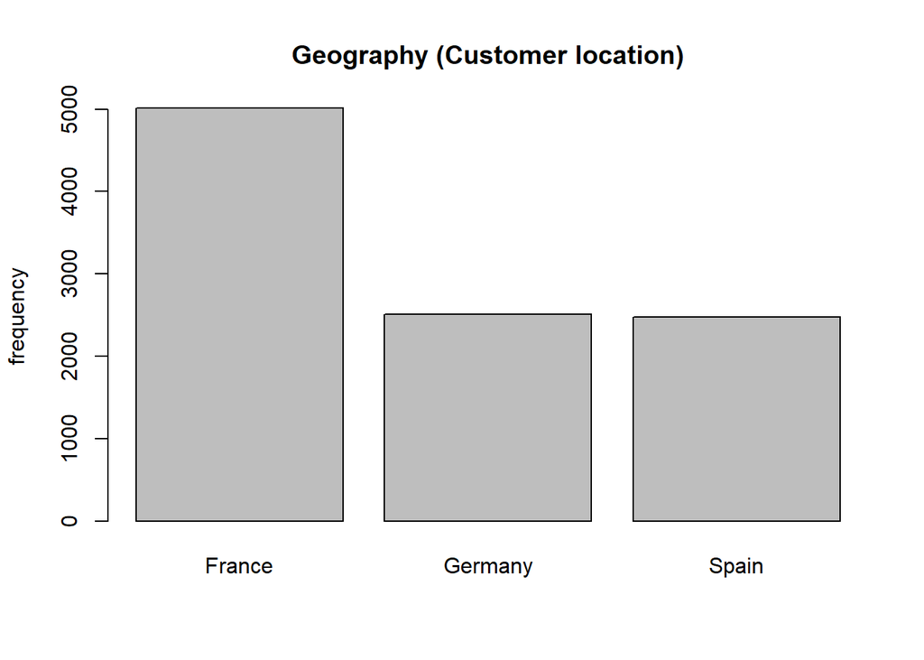

```r
counts <- with(bankdata,table(Geography))
barplot(counts,main="Geography (Customer location)",ylab="frequency")
```

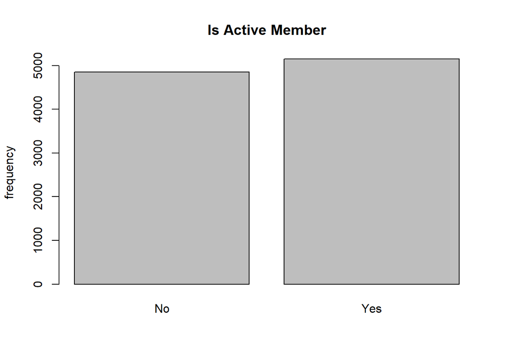

```r
counts <- with(bankdata,table(IsActiveMember))
barplot(counts,main="Is Active Member",ylab="frequency",names.arg=c("No", "Yes"))
```

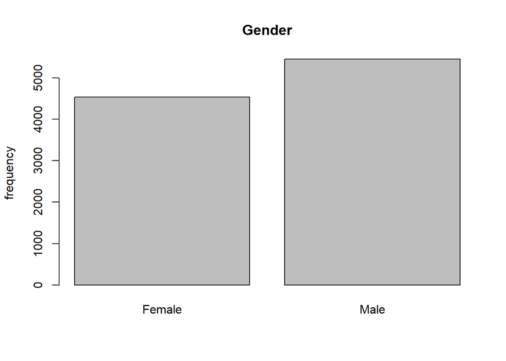

```r
counts <- with(bankdata,table(Gender))
barplot(counts,main="Gender",ylab="frequency")
```

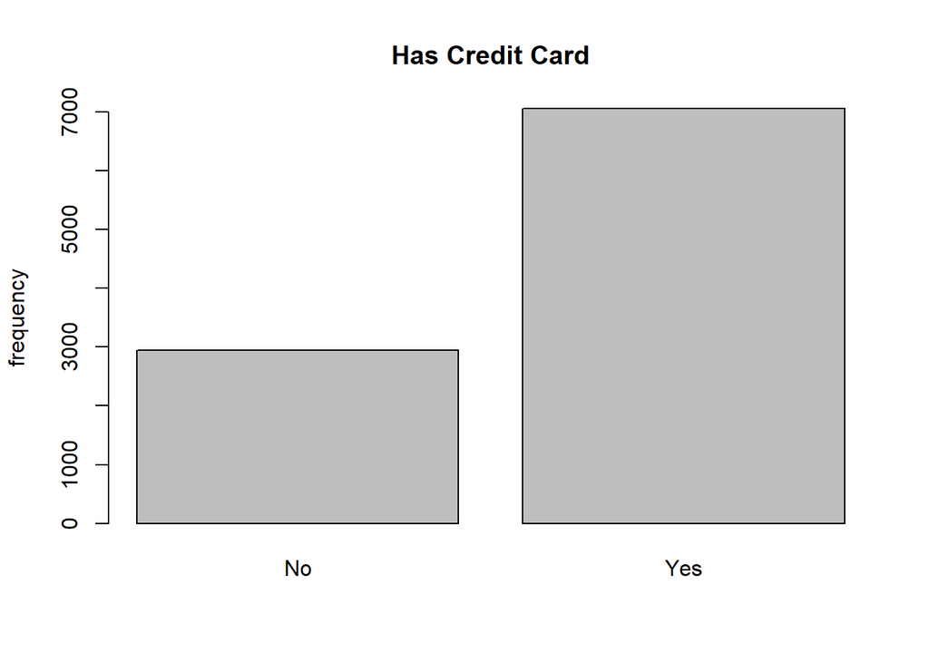

```r
counts <- with(bankdata,table(HasCrCard))
barplot(counts,main="Has Credit Card",ylab="frequency",names.arg=c("No", "Yes"))
```

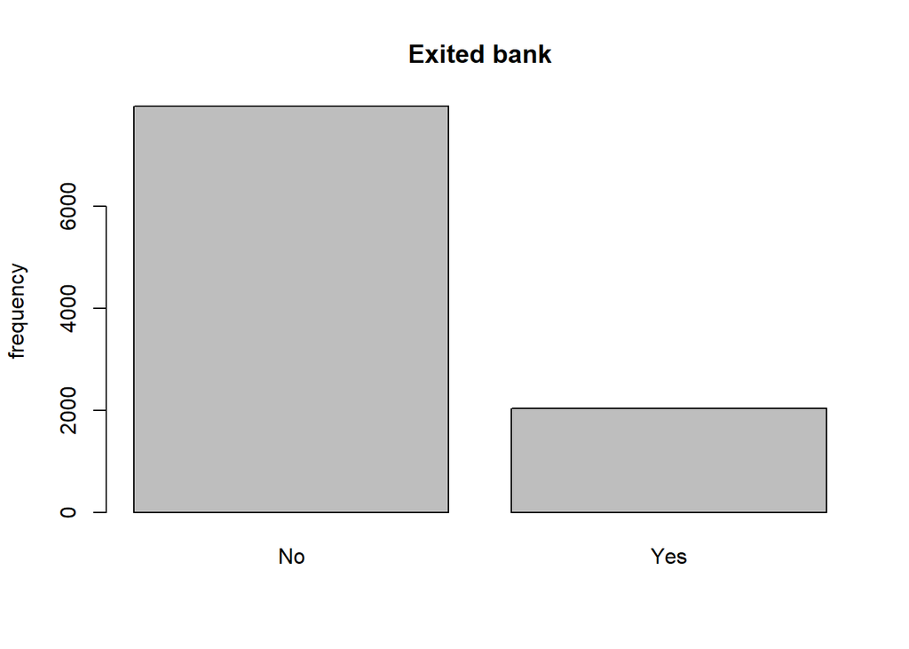

```r
counts <- with(bankdata,table(Exited))
barplot(counts,main="Exited bank",ylab="frequency",names.arg=c("No", "Yes"))
```

Histograms of quantitative variables

Age, Tenure, and Estimated Salary look fine.

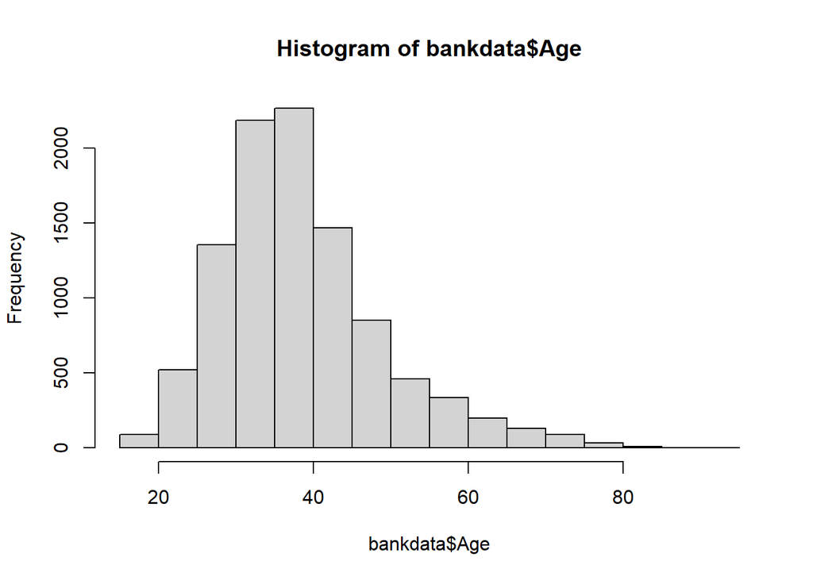

```r
hist(bankdata$Age)
```

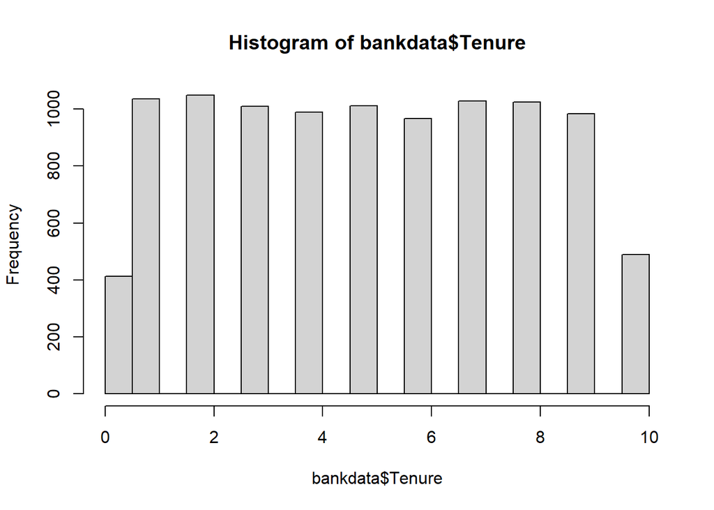

```r
hist(bankdata$Tenure) # uniform
```

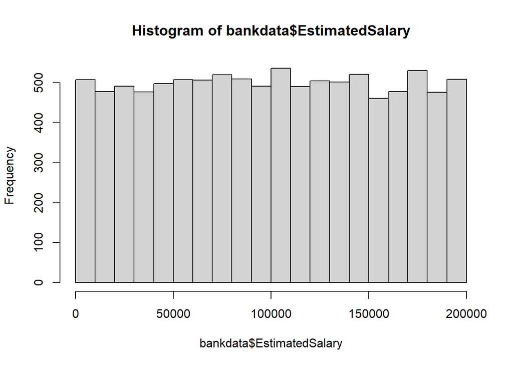

```r
hist(bankdata$EstimatedSalary) #uniform
```

Balance histogram shows significant amount of zero balances, over a third. Because the balance column represents checking account balance, we will treat a $0 balance as indicating the customer has some other product(s) from the bank than a checking account. It makes sense to act on this info by transforming Balance to a binary variable: balance/no balance

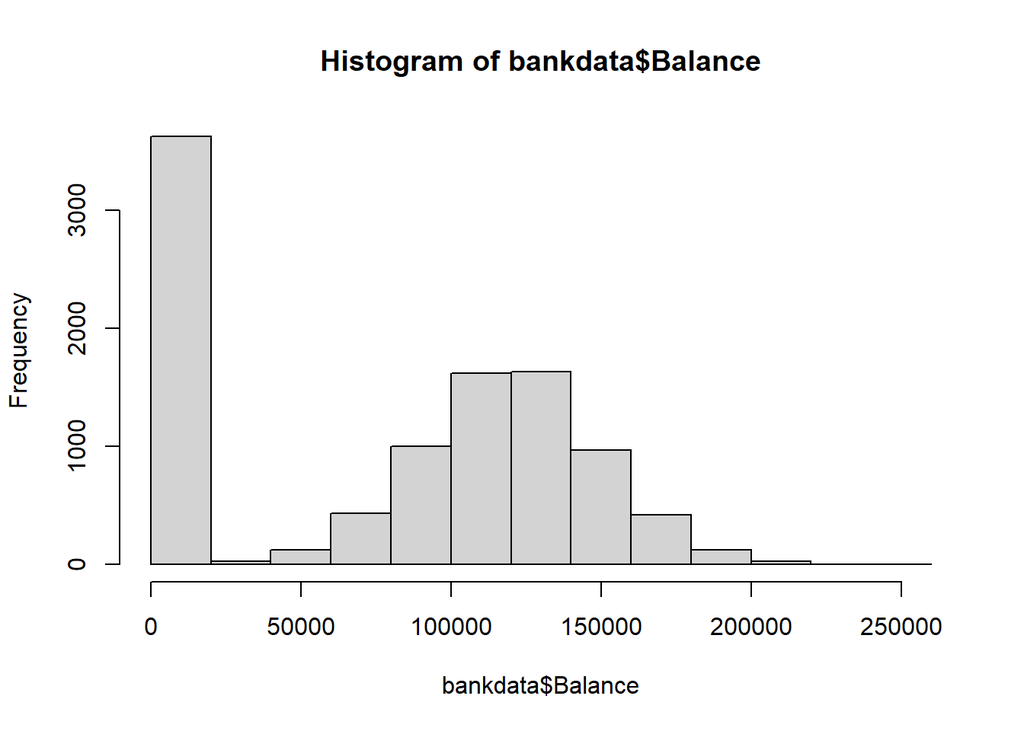

```r
hist(bankdata$Balance) # normal except a lot of 0 balances
```

```r
# Balance variable has many 0 balances, over a quarter of the data
# the minimum non-zero balance is $3768.69
summary(bankdata$Balance)
```

```
##    Min. 1st Qu.  Median    Mean 3rd Qu.    Max.
##       0       0   97199   76486  127644  250898
```

```r
banktemp <- arrange(bankdata,Balance)
bankfilter <- filter(banktemp, Balance > 0)
head(select(bankfilter,Balance))
```

```
## # A tibble: 6 x 1
##   Balance
##     <dbl>
## 1   3769.
## 2  12459.
## 3  14263.
## 4  16894.
## 5  23503.
## 6  24043.
```

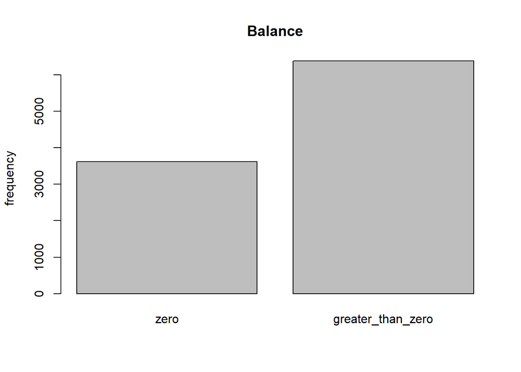

```r
# split Balance
bankdata <-mutate(bankdata,Balance_cat=cut(bankdata$Balance,breaks=c(0,1,1000000),labels=c("zero","greater_than_zero"),                                  include.lowest=TRUE,ordered_result=TRUE))

counts <- with(bankdata,table(Balance_cat))
barplot(counts,main="Balance",ylab="frequency")
```

Number of Products has very low frequencies beyond two products. We will transform this variable to a binary variable: one product/more than one product

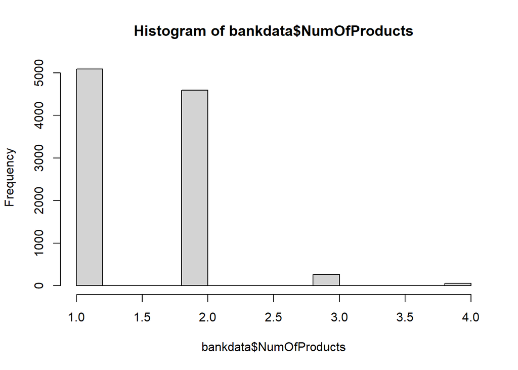

```r
hist(bankdata$NumOfProducts)
```

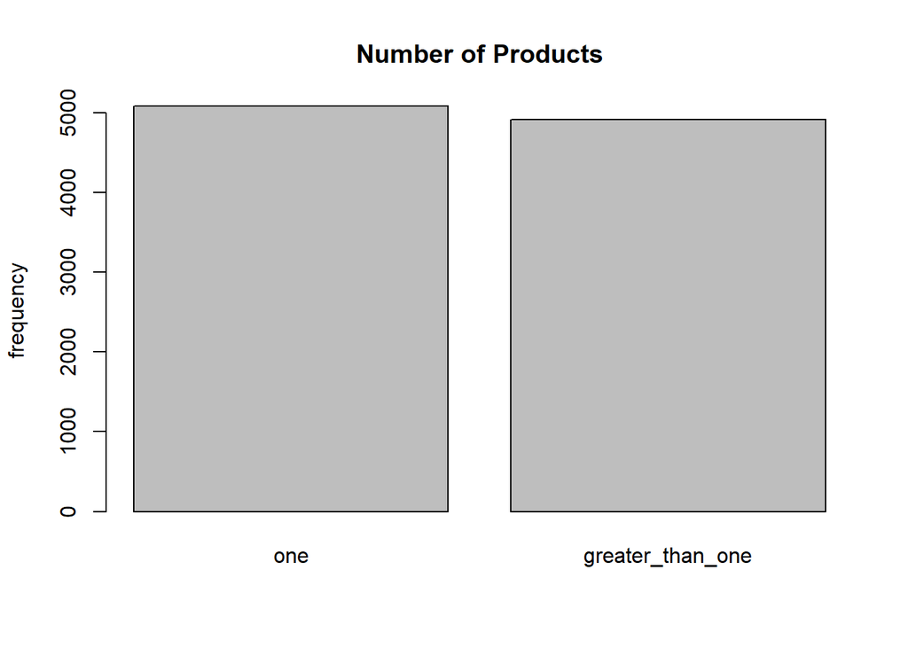

```r
# split Number Of Products
bankdata <- mutate(bankdata,NumOfProducts_cat=cut(bankdata$NumOfProducts,breaks=c(1,1.9,10),labels=c("one","greater_than_one"),include.lowest=TRUE,ordered_result=TRUE))

counts <- with(bankdata,table(NumOfProducts_cat))
barplot(counts,main="Number of Products",ylab="frequency")
```

Credit Scores are easier to understand categorized according to risk assessments determined by credit agencies. It is more meaningful to think in terms of changes from one catagory to the next than numerical changes in credit score. Here we adopt the Experian credit score categories (Experian.com) and transform CreditScore to an ordinal variable of five levels.

Credit score range  
very poor [300, 580) fair [580, 670) good [670, 740) very good [740, 800) exceptional [800, 850)

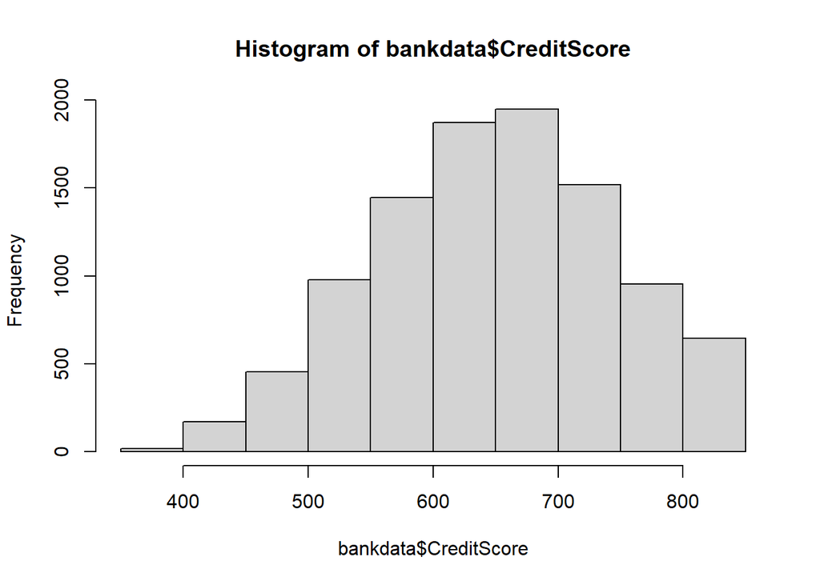

```r
hist(bankdata$CreditScore)
```

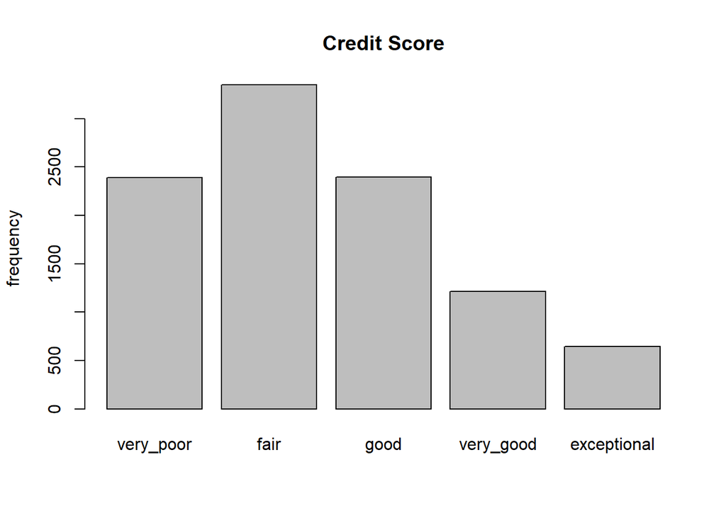

```r
# split Credit score
bankdata <- mutate(bankdata,CreditScore_cat=cut(bankdata$CreditScore,breaks=c(300,580,670,740,800,850),labels=c("very_poor","fair","good","very_good","exceptional"),                  include.lowest=TRUE,ordered_result=TRUE))

counts <- with(bankdata,table(CreditScore_cat))
barplot(counts,main="Credit Score",ylab="frequency")
```

In order to work with categorical variables we must create dummy columns. The base level for each categorical is determined alphabetically, with the exception of Credit Score, Balance, and Number of Products, which are determined ordinally (lowest becomes base).

```r
bankdata <- dummy_cols(bankdata, select_columns=c("CreditScore_cat","Balance_cat","Gender","Geography","NumOfProducts_cat"),remove_first_dummy = TRUE)
```

A check of multicollinearity between quantitative variables show no issues.

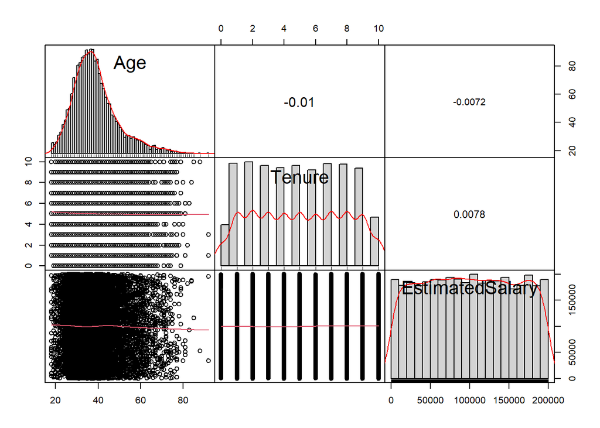

```r
# table of numerical variables only
bankdata_num <- select(bankdata,Age,Tenure,EstimatedSalary)

chart.Correlation(bankdata_num,
                  method="pearson",
                  histogram=TRUE,
                  pch=16)
```

Check interactions with categorical variables using Cramer V coefficent w/ bias correction Interactions: Balance / Geography Balance / Number of Products

```r
tb1 <- with(bankdata, table(Balance_cat,CreditScore_cat))
cramerV(tb1,bias.correct=TRUE)
```

```
## Cramer V
## 0.004911
```

```r
tb2 <- with(bankdata, table(Balance_cat,Gender))
cramerV(tb2,bias.correct=TRUE)
```

```
## Cramer V
##        0
```

```r
# correlation between Balance and Geography (Cramer V = 0.4354)
tb3 <- with(bankdata, table(Balance_cat,Geography))
cramerV(tb3,bias.correct=TRUE)
```

```
## Cramer V
##   0.4354
```

```r
tb4 <- with(bankdata, table(Balance_cat,HasCrCard))
cramerV(tb4,bias.correct=TRUE)
```

```
## Cramer V
##   0.0154
```

```r
tb5 <- with(bankdata, table(Balance_cat,IsActiveMember))
cramerV(tb5,bias.correct=TRUE)
```

```
## Cramer V
##        0
```

```r
# correlation between Balance and Number of Products (Cramer V = 0.3887)
tb6 <- with(bankdata, table(Balance_cat,NumOfProducts_cat))
cramerV(tb6,bias.correct=TRUE)
```

```
## Cramer V
##   0.3887
```

```r
tb7 <- with(bankdata, table(CreditScore_cat,Gender))
cramerV(tb7,bias.correct=TRUE)
```

```
## Cramer V
##        0
```

```r
tb8 <- with(bankdata, table(CreditScore_cat,Geography))
cramerV(tb8,bias.correct=TRUE)
```

```
## Cramer V
## 0.009216
```

```r
tb9 <- with(bankdata, table(CreditScore_cat,HasCrCard))
cramerV(tb9,bias.correct=TRUE)
```

```
## Cramer V
## 0.001515
```

```r
tb10 <- with(bankdata, table(CreditScore_cat,IsActiveMember))
cramerV(tb10,bias.correct=TRUE)
```

```
## Cramer V
##  0.01893
```

```r
tb11 <- with(bankdata, table(CreditScore_cat,NumOfProducts_cat))
cramerV(tb11,bias.correct=TRUE)
```

```
## Cramer V
##  0.01164
```

```r
tb12 <- with(bankdata, table(Gender, Geography))
cramerV(tb12,bias.correct=TRUE)
```

```
## Cramer V
##  0.02218
```

```r
tb13 <- with(bankdata, table(Gender,HasCrCard))
cramerV(tb13,bias.correct=TRUE)
```

```
## Cramer V
##        0
```

```r
tb14 <- with(bankdata, table(Gender,IsActiveMember))
cramerV(tb14,bias.correct=TRUE)
```

```
## Cramer V
##  0.02021
```

```r
tb15 <- with(bankdata, table(Gender,NumOfProducts_cat))
cramerV(tb15,bias.correct=TRUE)
```

```
## Cramer V
##        0
```

```r
tb16 <- with(bankdata, table(Geography,HasCrCard))
cramerV(tb16,bias.correct=TRUE)
```

```
## Cramer V
## 0.004849
```

```r
tb17 <- with(bankdata, table(Geography,IsActiveMember))
cramerV(tb17,bias.correct=TRUE)
```

```
## Cramer V
##  0.01818
```

```r
tb18 <- with(bankdata, table(Geography,NumOfProducts_cat))
cramerV(tb18,bias.correct=TRUE)
```

```
## Cramer V
##  0.03155
```

```r
tb19 <- with(bankdata, table(HasCrCard,IsActiveMember))
cramerV(tb19,bias.correct=TRUE)
```

```
## Cramer V
## 0.006387
```

```r
tb20 <- with(bankdata, table(HasCrCard,NumOfProducts_cat))
cramerV(tb20,bias.correct=TRUE)
```

```
## Cramer V
##        0
```

```r
tb21 <- with(bankdata, table(IsActiveMember,NumOfProducts_cat))
cramerV(tb21,bias.correct=TRUE)
```

```
## Cramer V
##  0.01996
```

Now we wish to check for correlations between continous and categorical variables. Use Logistic regression to check. Interactions Interactions: Age / Balance *Age / Gender* Age / Geography_Germany *Age / Is Active Member* Age / Number of Products ** *Tenure / Has Credit Card*

```r
# significant interaction (p < 0.01266)
test <- with(bankdata, glm(Balance_cat_greater_than_zero ~ Age,
                                   family="binomial"))
summary(test)
```

```
##
## Call:
## glm(formula = Balance_cat_greater_than_zero ~ Age, family = "binomial")
##
## Deviance Residuals:
##     Min       1Q   Median       3Q      Max
## -1.5815  -1.4079   0.9284   0.9578   1.0043
##
## Coefficients:
##             Estimate Std. Error z value Pr(>|z|)
## (Intercept)  0.29555    0.08053   3.670 0.000243 ***
## Age          0.00702    0.00201   3.492 0.000480 ***
## ---
## Signif. codes:  0 '***' 0.001 '**' 0.01 '*' 0.05 '.' 0.1 ' ' 1
##
## (Dispersion parameter for binomial family taken to be 1)
##
##     Null deviance: 13088  on 9999  degrees of freedom
## Residual deviance: 13075  on 9998  degrees of freedom
## AIC: 13079
##
## Number of Fisher Scoring iterations: 4
```

```r
test <- with(bankdata, glm(Balance_cat_greater_than_zero ~ EstimatedSalary,
                                   family="binomial"))
summary(test)
```

```
##
## Call:
## glm(formula = Balance_cat_greater_than_zero ~ EstimatedSalary,
##     family = "binomial")
##
## Deviance Residuals:
##     Min       1Q   Median       3Q      Max
## -1.4497  -1.4171   0.9361   0.9517   0.9677
##
## Coefficients:
##                  Estimate Std. Error z value Pr(>|z|)
## (Intercept)     5.156e-01  4.163e-02  12.385   <2e-16 ***
## EstimatedSalary 5.243e-07  3.620e-07   1.449    0.147
## ---
## Signif. codes:  0 '***' 0.001 '**' 0.01 '*' 0.05 '.' 0.1 ' ' 1
##
## (Dispersion parameter for binomial family taken to be 1)
##
##     Null deviance: 13088  on 9999  degrees of freedom
## Residual deviance: 13086  on 9998  degrees of freedom
## AIC: 13090
##
## Number of Fisher Scoring iterations: 4
```

```r
test <- with(bankdata, glm(Balance_cat_greater_than_zero ~ Tenure,
                                   family="binomial"))
summary(test)
```

```
##
## Call:
## glm(formula = Balance_cat_greater_than_zero ~ Tenure, family = "binomial")
##
## Deviance Residuals:
##     Min       1Q   Median       3Q      Max
## -1.4508  -1.4165   0.9350   0.9517   0.9685
##
## Coefficients:
##              Estimate Std. Error z value Pr(>|z|)
## (Intercept)  0.623096   0.041812  14.902   <2e-16 ***
## Tenure      -0.010965   0.007198  -1.523    0.128
## ---
## Signif. codes:  0 '***' 0.001 '**' 0.01 '*' 0.05 '.' 0.1 ' ' 1
##
## (Dispersion parameter for binomial family taken to be 1)
##
##     Null deviance: 13088  on 9999  degrees of freedom
## Residual deviance: 13085  on 9998  degrees of freedom
## AIC: 13089
##
## Number of Fisher Scoring iterations: 4
```

```r
test <- with(bankdata, glm(CreditScore_cat_fair ~ Age,
                                   family="binomial"))
summary(test)
```

```
##
## Call:
## glm(formula = CreditScore_cat_fair ~ Age, family = "binomial")
##
## Deviance Residuals:
##     Min       1Q   Median       3Q      Max
## -0.9367  -0.9040  -0.8990   1.4751   1.4948
##
## Coefficients:
##              Estimate Std. Error z value Pr(>|z|)
## (Intercept) -0.751124   0.081342  -9.234   <2e-16 ***
## Age          0.001681   0.002015   0.834    0.404
## ---
## Signif. codes:  0 '***' 0.001 '**' 0.01 '*' 0.05 '.' 0.1 ' ' 1
##
## (Dispersion parameter for binomial family taken to be 1)
##
##     Null deviance: 12753  on 9999  degrees of freedom
## Residual deviance: 12753  on 9998  degrees of freedom
## AIC: 12757
##
## Number of Fisher Scoring iterations: 4
```

```r
test <- with(bankdata, glm(CreditScore_cat_fair ~ EstimatedSalary,
                                   family="binomial"))
summary(test)
```

```
##
## Call:
## glm(formula = CreditScore_cat_fair ~ EstimatedSalary, family = "binomial")
##
## Deviance Residuals:
##     Min       1Q   Median       3Q      Max
## -0.9134  -0.9057  -0.8983   1.4728   1.4912
##
## Coefficients:
##                   Estimate Std. Error z value Pr(>|z|)
## (Intercept)     -6.584e-01  4.244e-02 -15.515   <2e-16 ***
## EstimatedSalary -2.729e-07  3.684e-07  -0.741    0.459
## ---
## Signif. codes:  0 '***' 0.001 '**' 0.01 '*' 0.05 '.' 0.1 ' ' 1
##
## (Dispersion parameter for binomial family taken to be 1)
##
##     Null deviance: 12753  on 9999  degrees of freedom
## Residual deviance: 12753  on 9998  degrees of freedom
## AIC: 12757
##
## Number of Fisher Scoring iterations: 4
```

```r
test <- with(bankdata, glm(CreditScore_cat_fair ~ Tenure,
                                   family="binomial"))
summary(test)
```

```
##
## Call:
## glm(formula = CreditScore_cat_fair ~ Tenure, family = "binomial")
##
## Deviance Residuals:
##     Min       1Q   Median       3Q      Max
## -0.9194  -0.9064  -0.8936   1.4712   1.4986
##
## Coefficients:
##              Estimate Std. Error z value Pr(>|z|)
## (Intercept) -0.729379   0.042553 -17.140   <2e-16 ***
## Tenure       0.008701   0.007327   1.188    0.235
## ---
## Signif. codes:  0 '***' 0.001 '**' 0.01 '*' 0.05 '.' 0.1 ' ' 1
##
## (Dispersion parameter for binomial family taken to be 1)
##
##     Null deviance: 12753  on 9999  degrees of freedom
## Residual deviance: 12752  on 9998  degrees of freedom
## AIC: 12756
##
## Number of Fisher Scoring iterations: 4
```

```r
test <- with(bankdata, glm(CreditScore_cat_good ~ Age,
                                   family="binomial"))
summary(test)
```

```
##
## Call:
## glm(formula = CreditScore_cat_good ~ Age, family = "binomial")
##
## Deviance Residuals:
##     Min       1Q   Median       3Q      Max
## -0.7453  -0.7415  -0.7398  -0.7330   1.7076
##
## Coefficients:
##               Estimate Std. Error z value Pr(>|z|)
## (Intercept) -1.1260185  0.0901178 -12.495   <2e-16 ***
## Age         -0.0007277  0.0022382  -0.325    0.745
## ---
## Signif. codes:  0 '***' 0.001 '**' 0.01 '*' 0.05 '.' 0.1 ' ' 1
##
## (Dispersion parameter for binomial family taken to be 1)
##
##     Null deviance: 11015  on 9999  degrees of freedom
## Residual deviance: 11015  on 9998  degrees of freedom
## AIC: 11019
##
## Number of Fisher Scoring iterations: 4
```

```r
test <- with(bankdata, glm(CreditScore_cat_good ~ EstimatedSalary,
                                   family="binomial"))
summary(test)
```

```
##
## Call:
## glm(formula = CreditScore_cat_good ~ EstimatedSalary, family = "binomial")
##
## Deviance Residuals:
##     Min       1Q   Median       3Q      Max
## -0.7437  -0.7414  -0.7393  -0.7371   1.6948
##
## Coefficients:
##                   Estimate Std. Error z value Pr(>|z|)
## (Intercept)     -1.165e+00  4.708e-02 -24.737   <2e-16 ***
## EstimatedSalary  1.035e-07  4.073e-07   0.254    0.799
## ---
## Signif. codes:  0 '***' 0.001 '**' 0.01 '*' 0.05 '.' 0.1 ' ' 1
##
## (Dispersion parameter for binomial family taken to be 1)
##
##     Null deviance: 11015  on 9999  degrees of freedom
## Residual deviance: 11015  on 9998  degrees of freedom
## AIC: 11019
##
## Number of Fisher Scoring iterations: 4
```

```r
test <- with(bankdata, glm(CreditScore_cat_good ~ Tenure,
                                   family="binomial"))
summary(test)
```

```
##
## Call:
## glm(formula = CreditScore_cat_good ~ Tenure, family = "binomial")
##
## Deviance Residuals:
##     Min       1Q   Median       3Q      Max
## -0.7525  -0.7452  -0.7355  -0.7283   1.7070
##
## Coefficients:
##              Estimate Std. Error z value Pr(>|z|)
## (Intercept) -1.117055   0.046654 -23.943   <2e-16 ***
## Tenure      -0.007459   0.008101  -0.921    0.357
## ---
## Signif. codes:  0 '***' 0.001 '**' 0.01 '*' 0.05 '.' 0.1 ' ' 1
##
## (Dispersion parameter for binomial family taken to be 1)
##
##     Null deviance: 11015  on 9999  degrees of freedom
## Residual deviance: 11014  on 9998  degrees of freedom
## AIC: 11018
##
## Number of Fisher Scoring iterations: 4
```

```r
test <- with(bankdata, glm(CreditScore_cat_very_good ~ Age,
                                   family="binomial"))
summary(test)
```

```
##
## Call:
## glm(formula = CreditScore_cat_very_good ~ Age, family = "binomial")
##
## Deviance Residuals:
##     Min       1Q   Median       3Q      Max
## -0.5150  -0.5107  -0.5090  -0.5061   2.0802
##
## Coefficients:
##              Estimate Std. Error z value Pr(>|z|)
## (Intercept) -1.932058   0.117897 -16.388   <2e-16 ***
## Age         -0.001190   0.002933  -0.406    0.685
## ---
## Signif. codes:  0 '***' 0.001 '**' 0.01 '*' 0.05 '.' 0.1 ' ' 1
##
## (Dispersion parameter for binomial family taken to be 1)
##
##     Null deviance: 7398.1  on 9999  degrees of freedom
## Residual deviance: 7397.9  on 9998  degrees of freedom
## AIC: 7401.9
##
## Number of Fisher Scoring iterations: 4
```

```r
test <- with(bankdata, glm(CreditScore_cat_very_good ~ EstimatedSalary,
                                   family="binomial"))
summary(test)
```

```
##
## Call:
## glm(formula = CreditScore_cat_very_good ~ EstimatedSalary, family = "binomial")
##
## Deviance Residuals:
##     Min       1Q   Median       3Q      Max
## -0.5105  -0.5096  -0.5088  -0.5080   2.0559
##
## Coefficients:
##                   Estimate Std. Error z value Pr(>|z|)
## (Intercept)     -1.972e+00  6.137e-02 -32.135   <2e-16 ***
## EstimatedSalary -6.205e-08  5.322e-07  -0.117    0.907
## ---
## Signif. codes:  0 '***' 0.001 '**' 0.01 '*' 0.05 '.' 0.1 ' ' 1
##
## (Dispersion parameter for binomial family taken to be 1)
##
##     Null deviance: 7398.1  on 9999  degrees of freedom
## Residual deviance: 7398.0  on 9998  degrees of freedom
## AIC: 7402
##
## Number of Fisher Scoring iterations: 4
```

```r
test <- with(bankdata, glm(CreditScore_cat_very_good ~ Tenure,
                                   family="binomial"))
summary(test)
```

```
##
## Call:
## glm(formula = CreditScore_cat_very_good ~ Tenure, family = "binomial")
##
## Deviance Residuals:
##     Min       1Q   Median       3Q      Max
## -0.5145  -0.5112  -0.5079  -0.5057   2.0632
##
## Coefficients:
##              Estimate Std. Error z value Pr(>|z|)
## (Intercept) -2.001643   0.061519 -32.537   <2e-16 ***
## Tenure       0.004643   0.010584   0.439    0.661
## ---
## Signif. codes:  0 '***' 0.001 '**' 0.01 '*' 0.05 '.' 0.1 ' ' 1
##
## (Dispersion parameter for binomial family taken to be 1)
##
##     Null deviance: 7398.1  on 9999  degrees of freedom
## Residual deviance: 7397.9  on 9998  degrees of freedom
## AIC: 7401.9
##
## Number of Fisher Scoring iterations: 4
```

```r
test <- with(bankdata, glm(CreditScore_cat_exceptional ~ Age,
                                   family="binomial"))
summary(test)
```

```
##
## Call:
## glm(formula = CreditScore_cat_exceptional ~ Age, family = "binomial")
##
## Deviance Residuals:
##     Min       1Q   Median       3Q      Max
## -0.3693  -0.3655  -0.3650  -0.3645   2.3451
##
## Coefficients:
##               Estimate Std. Error z value Pr(>|z|)
## (Intercept) -2.6916559  0.1563363 -17.217   <2e-16 ***
## Age          0.0004427  0.0038739   0.114    0.909
## ---
## Signif. codes:  0 '***' 0.001 '**' 0.01 '*' 0.05 '.' 0.1 ' ' 1
##
## (Dispersion parameter for binomial family taken to be 1)
##
##     Null deviance: 4783.5  on 9999  degrees of freedom
## Residual deviance: 4783.5  on 9998  degrees of freedom
## AIC: 4787.5
##
## Number of Fisher Scoring iterations: 5
```

```r
test <- with(bankdata, glm(CreditScore_cat_exceptional ~ EstimatedSalary,
                                   family="binomial"))
summary(test)
```

```
##
## Call:
## glm(formula = CreditScore_cat_exceptional ~ EstimatedSalary,
##     family = "binomial")
##
## Deviance Residuals:
##     Min       1Q   Median       3Q      Max
## -0.3669  -0.3660  -0.3650  -0.3641   2.3454
##
## Coefficients:
##                   Estimate Std. Error z value Pr(>|z|)
## (Intercept)     -2.685e+00  8.190e-02 -32.780   <2e-16 ***
## EstimatedSalary  1.011e-07  7.079e-07   0.143    0.886
## ---
## Signif. codes:  0 '***' 0.001 '**' 0.01 '*' 0.05 '.' 0.1 ' ' 1
##
## (Dispersion parameter for binomial family taken to be 1)
##
##     Null deviance: 4783.5  on 9999  degrees of freedom
## Residual deviance: 4783.5  on 9998  degrees of freedom
## AIC: 4787.5
##
## Number of Fisher Scoring iterations: 5
```

```r
test <- with(bankdata, glm(CreditScore_cat_exceptional ~ Tenure,
                                   family="binomial"))
summary(test)
```

```
##
## Call:
## glm(formula = CreditScore_cat_exceptional ~ Tenure, family = "binomial")
##
## Deviance Residuals:
##     Min       1Q   Median       3Q      Max
## -0.3693  -0.3668  -0.3652  -0.3627   2.3506
##
## Coefficients:
##              Estimate Std. Error z value Pr(>|z|)
## (Intercept) -2.651391   0.081062 -32.708   <2e-16 ***
## Tenure      -0.004609   0.014078  -0.327    0.743
## ---
## Signif. codes:  0 '***' 0.001 '**' 0.01 '*' 0.05 '.' 0.1 ' ' 1
##
## (Dispersion parameter for binomial family taken to be 1)
##
##     Null deviance: 4783.5  on 9999  degrees of freedom
## Residual deviance: 4783.4  on 9998  degrees of freedom
## AIC: 4787.4
##
## Number of Fisher Scoring iterations: 5
```

```r
# significant interaction (p < 0.04)
test <- with(bankdata, glm(Gender_Male ~ Age,
                                   family="binomial"))
summary(test)
```

```
##
## Call:
## glm(formula = Gender_Male ~ Age, family = "binomial")
##
## Deviance Residuals:
##    Min      1Q  Median      3Q     Max
## -1.304  -1.256   1.075   1.099   1.218
##
## Coefficients:
##              Estimate Std. Error z value Pr(>|z|)
## (Intercept)  0.388450   0.077218   5.031 4.89e-07 ***
## Age         -0.005267   0.001913  -2.753  0.00591 **
## ---
## Signif. codes:  0 '***' 0.001 '**' 0.01 '*' 0.05 '.' 0.1 ' ' 1
##
## (Dispersion parameter for binomial family taken to be 1)
##
##     Null deviance: 13779  on 9999  degrees of freedom
## Residual deviance: 13772  on 9998  degrees of freedom
## AIC: 13776
##
## Number of Fisher Scoring iterations: 3
```

```r
test <- with(bankdata, glm(Gender_Male ~ EstimatedSalary,
                                   family="binomial"))
summary(test)
```

```
##
## Call:
## glm(formula = Gender_Male ~ EstimatedSalary, family = "binomial")
##
## Deviance Residuals:
##    Min      1Q  Median      3Q     Max
## -1.269  -1.255   1.091   1.101   1.112
##
## Coefficients:
##                   Estimate Std. Error z value Pr(>|z|)
## (Intercept)      2.117e-01  4.034e-02   5.247 1.54e-07 ***
## EstimatedSalary -2.833e-07  3.493e-07  -0.811    0.417
## ---
## Signif. codes:  0 '***' 0.001 '**' 0.01 '*' 0.05 '.' 0.1 ' ' 1
##
## (Dispersion parameter for binomial family taken to be 1)
##
##     Null deviance: 13779  on 9999  degrees of freedom
## Residual deviance: 13779  on 9998  degrees of freedom
## AIC: 13783
##
## Number of Fisher Scoring iterations: 3
```

```r
test <- with(bankdata, glm(Gender_Male ~ Tenure,
                                   family="binomial"))
summary(test)
```

```
##
## Call:
## glm(formula = Gender_Male ~ Tenure, family = "binomial")
##
## Deviance Residuals:
##    Min      1Q  Median      3Q     Max
## -1.278  -1.252   1.084   1.101   1.122
##
## Coefficients:
##             Estimate Std. Error z value Pr(>|z|)
## (Intercept) 0.132055   0.040151   3.289  0.00101 **
## Tenure      0.010233   0.006946   1.473  0.14069
## ---
## Signif. codes:  0 '***' 0.001 '**' 0.01 '*' 0.05 '.' 0.1 ' ' 1
##
## (Dispersion parameter for binomial family taken to be 1)
##
##     Null deviance: 13779  on 9999  degrees of freedom
## Residual deviance: 13777  on 9998  degrees of freedom
## AIC: 13781
##
## Number of Fisher Scoring iterations: 3
```

```r
# very significant interaction
test <- with(bankdata, glm(Geography_Germany ~ Age,
                                   family="binomial"))
summary(test)
```

```
##
## Call:
## glm(formula = Geography_Germany ~ Age, family = "binomial")
##
## Deviance Residuals:
##     Min       1Q   Median       3Q      Max
## -0.9499  -0.7661  -0.7430   1.4957   1.7589
##
## Coefficients:
##              Estimate Std. Error z value Pr(>|z|)
## (Intercept) -1.488666   0.087999 -16.917  < 2e-16 ***
## Age          0.010074   0.002152   4.682 2.84e-06 ***
## ---
## Signif. codes:  0 '***' 0.001 '**' 0.01 '*' 0.05 '.' 0.1 ' ' 1
##
## (Dispersion parameter for binomial family taken to be 1)
##
##     Null deviance: 11266  on 9999  degrees of freedom
## Residual deviance: 11245  on 9998  degrees of freedom
## AIC: 11249
##
## Number of Fisher Scoring iterations: 4
```

```r
test <- with(bankdata, glm(Geography_Germany ~ EstimatedSalary,
                                   family="binomial"))
summary(test)
```

```
##
## Call:
## glm(formula = Geography_Germany ~ EstimatedSalary, family = "binomial")
##
## Deviance Residuals:
##     Min       1Q   Median       3Q      Max
## -0.7738  -0.7644  -0.7556   1.6445   1.6816
##
## Coefficients:
##                   Estimate Std. Error z value Pr(>|z|)
## (Intercept)     -1.135e+00  4.654e-02  -24.39   <2e-16 ***
## EstimatedSalary  4.130e-07  4.012e-07    1.03    0.303
## ---
## Signif. codes:  0 '***' 0.001 '**' 0.01 '*' 0.05 '.' 0.1 ' ' 1
##
## (Dispersion parameter for binomial family taken to be 1)
##
##     Null deviance: 11266  on 9999  degrees of freedom
## Residual deviance: 11265  on 9998  degrees of freedom
## AIC: 11269
##
## Number of Fisher Scoring iterations: 4
```

```r
test <- with(bankdata, glm(Geography_Germany ~ Tenure,
                                   family="binomial"))
summary(test)
```

```
##
## Call:
## glm(formula = Geography_Germany ~ Tenure, family = "binomial")
##
## Deviance Residuals:
##     Min       1Q   Median       3Q      Max
## -0.7609  -0.7604  -0.7598   1.6619   1.6640
##
## Coefficients:
##               Estimate Std. Error z value Pr(>|z|)
## (Intercept) -1.0915495  0.0461451 -23.655   <2e-16 ***
## Tenure      -0.0004526  0.0079759  -0.057    0.955
## ---
## Signif. codes:  0 '***' 0.001 '**' 0.01 '*' 0.05 '.' 0.1 ' ' 1
##
## (Dispersion parameter for binomial family taken to be 1)
##
##     Null deviance: 11266  on 9999  degrees of freedom
## Residual deviance: 11266  on 9998  degrees of freedom
## AIC: 11270
##
## Number of Fisher Scoring iterations: 4
```